```python
## Set Python - Spark environment.
import os
import sys
os.environ["SPARK_HOME"] = "/usr/hdp/current/spark2-client"
os.environ["PYLIB"] = os.environ["SPARK_HOME"] + "/python/lib"
sys.path.insert(0, os.environ["PYLIB"] + "/py4j-0.10.6-src.zip")
sys.path.insert(0, os.environ["PYLIB"] + "/pyspark.zip")
```

```python
## Create SparkContext, SparkSession
from os.path import expanduser, join, abspath

from pyspark.sql import SparkSession
from pyspark.sql import Row
from pyspark import SparkContext
sc = SparkContext()

# warehouse_location points to the default location for managed databases and tables
warehouse_location = 'hdfs:///apps/hive/warehouse/'

spark = SparkSession \
    .builder \
    .appName("Spark Machine Learning Example") \
    .config("spark.sql.warehouse.dir", warehouse_location) \
    .enableHiveSupport() \
    .getOrCreate()
```

```python
from pyspark.sql.types import *
from pyspark.sql.functions import *
```

```python
import numpy as np
import StringIO
import pandas as pd
import warnings
```

```python
# Plotting libraries
import matplotlib.pyplot as plt
import seaborn as sns

import plotly
plotly.tools.set_credentials_file(username='', api_key='')

import plotly.figure_factory as ff
import plotly.plotly as py
import plotly.offline as pyoff
import plotly.graph_objs as go

# Initializing some settings
sns.set_style('whitegrid')
sns.set(color_codes=True)
warnings.filterwarnings('ignore')
pyoff.init_notebook_mode(connected=True)
get_ipython().magic('matplotlib inline')
```

Problem Statement

The dataset is from a bank, data related to direct marketing campaigns of a Portuguese banking institution. The marketing campaigns were based on phone calls. Often, more than one contact to the same client was required, to access if the product (bank term deposit) would be (or not) subscribed. The data and attribute description are in the folder.

Dataset Description

The dataset has the following attributes: 1 - age (numeric) 2 - job : type of job (categorical: "admin.","unknown","unemployed","management","housemaid","entrepreneur","student", "blue-collar","self-employed","retired","technician","services") 3 - marital_status : marital status (categorical: "married","divorced","single"; note: "divorced" means divorced or widowed) 4 - education (categorical: "unknown","secondary","primary","tertiary") 5 - default: has credit in default? (binary: "yes","no") 6 - balance: average yearly balance, in euros (numeric) 7 - housing: has housing loan? (binary: "yes","no") 8 - loan: has personal loan? (binary: "yes","no") 9 - contact: contact communication type (categorical: "unknown","telephone","cellular") 10 - day: last contact day of the month (numeric) 11 - month: last contact month of year (categorical: "jan", "feb", "mar", ..., "nov", "dec") 12 - duration: last contact duration, in seconds (numeric) 13 - campaign: number of contacts performed during this campaign and for this client (numeric, includes last contact) 14 - pdays: number of days that passed by after the client was last contacted from a previous campaign (numeric, -1 means client was not previously contacted) 15 - previous: number of contacts performed before this campaign and for this client (numeric) 16 - poutcome: outcome of the previous marketing campaign (categorical: "unknown","other","failure","success") 17 - term_deposit_no_yes - has the client subscribed to a term deposit? (binary: "yes","no")

Define the Schema with the above data dictionary

```python
## Define Schema
bankDataSchema = StructType([
         StructField("age", IntegerType(), True),
         StructField("job", StringType(), True),
         StructField("marital_status", StringType(), True),
         StructField("education", StringType(), True),
         StructField("default", StringType(), True),
         StructField("balance", DoubleType(), True),
         StructField("housing", StringType(), True),
         StructField("loan", StringType(), True),
         StructField("contact", StringType(), True),
         StructField("day", IntegerType(), True),
         StructField("month", StringType(), True),
         StructField("duration", DoubleType(), True),
         StructField("campaign", DoubleType(), True),
         StructField("pdays", DoubleType(), True),
         StructField("previous", DoubleType(), True),
         StructField("poutcome", StringType(), True),
         StructField("term_deposit_no_yes", StringType(), True)])
```

```python
#Read data and create a dataframe
bankDF = spark.read.format("csv")\
        .option("header", "false")\
        .option("inferSchema", "true")\
        .load("file:///home/rameshm/Datasets/bank_data.csv", schema = bankDataSchema)
```

```python
#Verify Schema
bankDF.printSchema()
```

```
root
 |-- age: integer (nullable = true)
 |-- job: string (nullable = true)
 |-- marital_status: string (nullable = true)
 |-- education: string (nullable = true)
 |-- default: string (nullable = true)
 |-- balance: double (nullable = true)
 |-- housing: string (nullable = true)
 |-- loan: string (nullable = true)
 |-- contact: string (nullable = true)
 |-- day: integer (nullable = true)
 |-- month: string (nullable = true)
 |-- duration: double (nullable = true)
 |-- campaign: double (nullable = true)
 |-- pdays: double (nullable = true)
 |-- previous: double (nullable = true)
 |-- poutcome: string (nullable = true)
 |-- term_deposit_no_yes: string (nullable = true)
```

```python
#Verify first few records
bankDF.show(2)
```

```
+---+----------+--------------+---------+-------+-------+-------+----+--------+---+-----+--------+--------+-----+--------+--------+-------------------+
|age|       job|marital_status|education|default|balance|housing|loan| contact|day|month|duration|campaign|pdays|previous|poutcome|term_deposit_no_yes|
+---+----------+--------------+---------+-------+-------+-------+----+--------+---+-----+--------+--------+-----+--------+--------+-------------------+
| 30|unemployed|       married|  primary|     no| 1787.0|     no|  no|cellular| 19|  oct|    79.0|     1.0| -1.0|     0.0| unknown|                 no|
| 33|  services|       married|secondary|     no| 4789.0|    yes| yes|cellular| 11|  may|   220.0|     1.0|339.0|     4.0| failure|                 no|
+---+----------+--------------+---------+-------+-------+-------+----+--------+---+-----+--------+--------+-----+--------+--------+-------------------+
only showing top 2 rows
```

```python
#Verify the total rows and columns
## To Count the number of rows in DataFrame
print('Total records count is {}'.format(bankDF.count()))
## Columns count and column names
print("Total Columns count is {}".format(len(bankDF.columns)))
print("\n\nColumns are: {} \n".format(bankDF.columns))
```

```
Total records count is 4521
Total Columns count is 17


Columns are: ['age', 'job', 'marital_status', 'education', 'default', 'balance', 'housing', 'loan', 'contact', 'day', 'month', 'duration', 'campaign', 'pdays', 'previous', 'poutcome', 'term_deposit_no_yes']
```

```python
#Verify the Summary Statistics
## To get the summary statistics (mean, standard deviance, min ,max , count) of columns in a DataFrame
bankDF.describe().show()
```

```
+-------+------------------+-------+--------------+---------+-------+------------------+-------+----+--------+------------------+-----+------------------+------------------+------------------+------------------+--------+-------------------+
|summary|               age|    job|marital_status|education|default|           balance|housing|loan| contact|               day|month|          duration|          campaign|             pdays|          previous|poutcome|term_deposit_no_yes|
+-------+------------------+-------+--------------+---------+-------+------------------+-------+----+--------+------------------+-----+------------------+------------------+------------------+------------------+--------+-------------------+
|  count|              4521|   4521|          4521|     4521|   4521|              4521|   4521|4521|    4521|              4521| 4521|              4521|              4521|              4521|              4521|    4521|               4521|
|   mean| 41.17009511170095|   null|          null|     null|   null|1422.6578190665782|   null|null|    null|15.915284229152842| null|263.96129174961294| 2.793629727936297|39.766644547666445|0.5425790754257908|    null|               null|
| stddev|10.576210958711263|   null|          null|     null|   null|3009.6381424673395|   null|null|    null| 8.247667327229934| null|259.85663262468216|3.1098066601885823|100.12112444301656|1.6935623506071211|    null|               null|
|    min|                19| admin.|      divorced|  primary|     no|           -3313.0|     no|  no|cellular|                 1|  apr|               4.0|               1.0|              -1.0|               0.0| failure|                 no|
|    max|                87|unknown|        single|  unknown|    yes|           71188.0|    yes| yes| unknown|                31|  sep|            3025.0|              50.0|             871.0|              25.0| unknown|                yes|
+-------+------------------+-------+--------------+---------+-------+------------------+-------+----+--------+------------------+-----+------------------+------------------+------------------+------------------+--------+-------------------+
```

```python
## Verify summary stats for few fields
bankDF.describe().select('summary', 'age', 'loan', 'balance', 'pdays').show()
```

```
+-------+------------------+----+------------------+------------------+
|summary|               age|loan|           balance|             pdays|
+-------+------------------+----+------------------+------------------+
|  count|              4521|4521|              4521|              4521|
|   mean| 41.17009511170095|null|1422.6578190665782|39.766644547666445|
| stddev|10.576210958711263|null|3009.6381424673395|100.12112444301656|
|    min|                19|  no|           -3313.0|              -1.0|
|    max|                87| yes|           71188.0|             871.0|
+-------+------------------+----+------------------+------------------+
```

```python
## Find the Distinct values count in each column
bankDF.agg(*(countDistinct(col(c)).alias(c) for c in bankDF.columns)).show()
```

```
+---+---+--------------+---------+-------+-------+-------+----+-------+---+-----+--------+--------+-----+--------+--------+-------------------+
|age|job|marital_status|education|default|balance|housing|loan|contact|day|month|duration|campaign|pdays|previous|poutcome|term_deposit_no_yes|
+---+---+--------------+---------+-------+-------+-------+----+-------+---+-----+--------+--------+-----+--------+--------+-------------------+
| 67| 12|             3|        4|      2|   2353|      2|   2|      3| 31|   12|     875|      32|  292|      24|       4|                  2|
+---+---+--------------+---------+-------+-------+-------+----+-------+---+-----+--------+--------+-----+--------+--------+-------------------+
```

```python
## Find maximum value in each column
bankDF.agg(*(max(col(c)).alias(c) for c in bankDF.columns)).show()
```

```
+---+-------+--------------+---------+-------+-------+-------+----+-------+---+-----+--------+--------+-----+--------+--------+-------------------+
|age|    job|marital_status|education|default|balance|housing|loan|contact|day|month|duration|campaign|pdays|previous|poutcome|term_deposit_no_yes|
+---+-------+--------------+---------+-------+-------+-------+----+-------+---+-----+--------+--------+-----+--------+--------+-------------------+
| 87|unknown|        single|  unknown|    yes|71188.0|    yes| yes|unknown| 31|  sep|  3025.0|    50.0|871.0|    25.0| unknown|                yes|
+---+-------+--------------+---------+-------+-------+-------+----+-------+---+-----+--------+--------+-----+--------+--------+-------------------+
```

# Observation:

The minimum value in the balance column is negative Verify how many such negative values exists in the balance column

```python
print("Total count of negative values in balance column are: {}".format(bankDF.where(bankDF.balance < 0).count()))
```

```
Total count of negative values in balance column are: 366
```

Data Pre-Processing

Replace the negative balances with the ZEROES

```python
## Replace negative balances with zeroes
from pyspark.sql.functions import when
bankDF = bankDF.withColumn('balance', when(bankDF.balance > 0, bankDF.balance).otherwise(0))
zeroBalance = bankDF.where(bankDF.balance < 0)
zeroBalance.count()
```

```
0
```

Define a table/view to run sql queries on the dataframe

```python
## Create view/table
bankDF.createOrReplaceTempView("bankDFTable")
```

```python
#Verify the target distribution
resultDF = spark.sql("""
SELECT term_deposit_no_yes, COUNT(*) AS Count
FROM bankDFTable
GROUP BY term_deposit_no_yes
""")

resultDF.show()
```

```
+-------------------+-----+
|term_deposit_no_yes|Count|
+-------------------+-----+
|                 no| 4000|
|                yes|  521|
+-------------------+-----+
```

```python
pdDF = resultDF.toPandas()
data = [
    go.Bar(
        x=pdDF['term_deposit_no_yes'], # assign x as the dataframe column 'x'
        y=pdDF['Count']
    )
]
layout = go.Layout(title='Term Deposit Opted Yes/No Counts',)
fig = go.Figure(data=data, layout=layout)
py.iplot(fig, filename='basic-bar')
```

[interactive chart not shown]

```python
#Pair wise frequency between Target (term_deposit_no_yes) and loan columns
resultDF = bankDF.crosstab("term_deposit_no_yes", "loan")
```

```python
resultDF.show()
```

```
+------------------------+----+---+
|term_deposit_no_yes_loan|  no|yes|
+------------------------+----+---+
|                     yes| 478| 43|
|                      no|3352|648|
+------------------------+----+---+
```

```python
pdDF = resultDF.toPandas()
pdDF.columns = ['term_deposit_no_yes', 'No_Existing_Loans', 'Existing_Loan']
trace1 = go.Bar(
    x=['Opted', 'Not Opted'],
    y=pdDF['No_Existing_Loans'],
    name='No Existing Loans'
)

trace2 = go.Bar(
    x=['Opted', 'Not Opted'],
    y=pdDF['Existing_Loan'],
    name='Existing Loans'
)

data = [trace1, trace2]
layout = go.Layout(
    title='Term Deposit vs Loan Counts',
    barmode='group'
)

fig = go.Figure(data=data, layout=layout)
py.iplot(fig, filename='grouped-bar')
```

[interactive chart not shown]

```python
#Term Deposit Opted Counts for different job categories
resultDF = spark.sql("""
SELECT
    job,
    COUNT(*) AS loan_denied_count
    FROM bankDFTable
    WHERE term_deposit_no_yes = "yes"
    GROUP BY job
""")
```

```python
pdDF = resultDF.toPandas()
data = [
    go.Bar(
        x=pdDF['job'], # assign x as the dataframe column 'x'
        y=pdDF['loan_denied_count']
    )
]
layout = go.Layout(title='Term Deposit Count in each Job Category',)
fig = go.Figure(data=data, layout=layout)
py.iplot(fig, filename='basic-bar')
```

[interactive chart not shown]

```python
#Term Deposit Not-Opted Counts for different job categories
resultDF = spark.sql("""
SELECT
    job,
    COUNT(*) AS loan_denied_count
    FROM bankDFTable
    WHERE term_deposit_no_yes = "no"
    GROUP BY job
""")
```

```python
pdDF = resultDF.toPandas()
data = [
    go.Bar(
        x=pdDF['job'], # assign x as the dataframe column 'x'
        y=pdDF['loan_denied_count']
    )
]
layout = go.Layout(title='Term Deposit Count in each Job Category',)
fig = go.Figure(data=data, layout=layout)
py.iplot(fig, filename='basic-bar')
```

[interactive chart not shown]

```python
#Term Deposits Counts for different education levels
resultDF = bankDF.filter(expr("term_deposit_no_yes = 'yes'")).groupBy("education").count()
```

```python
resultDF.show()
```

```
+---------+-----+
|education|count|
+---------+-----+
|  unknown|   19|
| tertiary|  193|
|secondary|  245|
|  primary|   64|
+---------+-----+
```

```python
pdDF = resultDF.toPandas()
data = [
    go.Bar(
        x=pdDF['education'], # assign x as the dataframe column 'x'
        y=pdDF['count']
    )
]
layout = go.Layout(title='Term Deposit Opted Count in each Education Level',)
fig = go.Figure(data=data, layout=layout)
py.iplot(fig, filename='basic-bar')
```

[interactive chart not shown]

```python
#Pair wise frequency between Target (term_deposit_no_yes) and marital_status columns
resultDF = bankDF.crosstab('term_deposit_no_yes', 'marital_status')
```

```python
resultDF.show()
```

```
+----------------------------------+--------+-------+------+
|term_deposit_no_yes_marital_status|divorced|married|single|
+----------------------------------+--------+-------+------+
|                               yes|      77|    277|   167|
|                                no|     451|   2520|  1029|
+----------------------------------+--------+-------+------+
```

```python
resultDF = spark.sql("""
SELECT term_deposit_no_yes,
    SUM(CASE WHEN marital_status = 'divorced' THEN 1 ELSE 0 END) divorced_Count,
    SUM(CASE WHEN marital_status = 'married' THEN 1 ELSE 0 END) married_Count,
    SUM(CASE WHEN marital_status = 'single' THEN 1 ELSE 0 END) single_Count
from bankDFTable
GROUP BY term_deposit_no_yes
""")
```

```python
resultDF.show()
```

```
+-------------------+--------------+-------------+------------+
|term_deposit_no_yes|divorced_Count|married_Count|single_Count|
+-------------------+--------------+-------------+------------+
|                 no|           451|         2520|        1029|
|                yes|            77|          277|         167|
+-------------------+--------------+-------------+------------+
```

```python
pdDF = resultDF.toPandas()
trace1 = go.Bar(
    x=pdDF['term_deposit_no_yes'],
    y=pdDF['divorced_Count'],
    name='Divorced Count'
)

trace2 = go.Bar(
    x=pdDF['term_deposit_no_yes'],
    y=pdDF['married_Count'],
    name='Married Count'
)

trace3 = go.Bar(
    x=pdDF['term_deposit_no_yes'],
    y=pdDF['single_Count'],
    name='Single Count'
)

data = [trace1, trace2, trace3]
layout = go.Layout(
    title='term depoisit opted/not-opted vs marital_status Counts',
    barmode='group'
)

fig = go.Figure(data=data, layout=layout)
py.iplot(fig, filename='grouped-bar')
```

[interactive chart not shown]

```python
#Pair wise frequency between Target (term_deposit_no_yes) and default columns
resultDF = bankDF.crosstab('default', 'term_deposit_no_yes')
resultDF.show()
```

```
+---------------------------+----+---+
|default_term_deposit_no_yes|  no|yes|
+---------------------------+----+---+
|                        yes|  67|  9|
|                         no|3933|512|
+---------------------------+----+---+
```

```python
pdDF = resultDF.toPandas()
trace1 = go.Bar(
    x=['Defaulted_Yes', 'Defaulted_No'],
    y=pdDF['no'],
    name='Not Opted'
)

trace2 = go.Bar(
    x=['Defaulted_Yes', 'Defaulted_No'],
    y=pdDF['yes'],
    name='Opted'
)

data = [trace1, trace2]
layout = go.Layout(
    title='Default vs term deposit Counts',
    barmode='group'
)

fig = go.Figure(data=data, layout=layout)
py.iplot(fig, filename='grouped-bar')
```

[interactive chart not shown]

```python
#Convert Spark DataFrame into Pandas DataFrame

bankDF_pd = bankDF.toPandas()
bankDF_pd.head()
```

|  | age | job | marital_status | education | default | balance | housing | loan | contact | day | month | duration | campaign | pdays | previous | poutcome | term_deposit_no_yes |
| --- | --- | --- | --- | --- | --- | --- | --- | --- | --- | --- | --- | --- | --- | --- | --- | --- | --- |
| 0 | 30 | unemployed | married | primary | no | 1787.0 | no | no | cellular | 19 | oct | 79.0 | 1.0 | -1.0 | 0.0 | unknown | no |
| 1 | 33 | services | married | secondary | no | 4789.0 | yes | yes | cellular | 11 | may | 220.0 | 1.0 | 339.0 | 4.0 | failure | no |
| 2 | 35 | management | single | tertiary | no | 1350.0 | yes | no | cellular | 16 | apr | 185.0 | 1.0 | 330.0 | 1.0 | failure | no |
| 3 | 30 | management | married | tertiary | no | 1476.0 | yes | yes | unknown | 3 | jun | 199.0 | 4.0 | -1.0 | 0.0 | unknown | no |
| 4 | 59 | blue-collar | married | secondary | no | 0.0 | yes | no | unknown | 5 | may | 226.0 | 1.0 | -1.0 | 0.0 | unknown | no |

```python
#Derive Correlations for the numeric columns
correlations = bankDF_pd.corr()
correlations
```

|  | age | balance | day | duration | campaign | pdays | previous |
| --- | --- | --- | --- | --- | --- | --- | --- |
| age | 1.000000 | 0.084202 | -0.017853 | -0.002367 | -0.005148 | -0.008894 | -0.003511 |
| balance | 0.084202 | 1.000000 | -0.007595 | -0.015195 | -0.010840 | 0.008616 | 0.026031 |
| day | -0.017853 | -0.007595 | 1.000000 | -0.024629 | 0.160706 | -0.094352 | -0.059114 |
| duration | -0.002367 | -0.015195 | -0.024629 | 1.000000 | -0.068382 | 0.010380 | 0.018080 |
| campaign | -0.005148 | -0.010840 | 0.160706 | -0.068382 | 1.000000 | -0.093137 | -0.067833 |
| pdays | -0.008894 | 0.008616 | -0.094352 | 0.010380 | -0.093137 | 1.000000 | 0.577562 |
| previous | -0.003511 | 0.026031 | -0.059114 | 0.018080 | -0.067833 | 0.577562 | 1.000000 |

```python
#Verify for Null Values
bankDF.select([count(when(isnan(c) | col(c).isNull(), c)).alias(c) for c in bankDF.columns]).show()
```

```
+---+---+--------------+---------+-------+-------+-------+----+-------+---+-----+--------+--------+-----+--------+--------+-------------------+
|age|job|marital_status|education|default|balance|housing|loan|contact|day|month|duration|campaign|pdays|previous|poutcome|term_deposit_no_yes|
+---+---+--------------+---------+-------+-------+-------+----+-------+---+-----+--------+--------+-----+--------+--------+-------------------+
|  0|  0|             0|        0|      0|      0|      0|   0|      0|  0|    0|       0|       0|    0|       0|       0|                  0|
+---+---+--------------+---------+-------+-------+-------+----+-------+---+-----+--------+--------+-----+--------+--------+-------------------+
```

```python
#Remove Null values - if any
data_df = bankDF.na.drop( how = 'any' )
print('Before Dropping Null Values', bankDF.count())
print('After Dropping Null Values', data_df.count())
```

```
('Before Dropping Null Values', 4521)
('After Dropping Null Values', 4521)
```

```python
#Split the data into training and test sets (30% held out for testing)
(trainingData, testData) = bankDF.randomSplit([0.7, 0.3])
```

Define PipeLines

Stages:

- Preprocessing
- Model Building & Evaluation

Extract Categorical and Numerical Columns from the data

```python
cat_Var_Names = ['job', 'marital_status', 'education', 'default', 'housing',
                 'day', 'contact', 'month', 'poutcome', 'term_deposit_no_yes']

num_Var_Names = ['age', 'balance', 'duration', 'previous', 'pdays', 'campaign']
```

Use VectorAssembler to combine a given list of numcolumns into a single vector column.¶

```python
from pyspark.ml.feature import VectorAssembler

vector_assembler_NumVars = VectorAssembler(inputCols=num_Var_Names, outputCol="num_features_all")
```

Scale all the numeric attributes using MinMaxScaler

# MinMaxScaler transforms a dataset of Vector rows, rescaling each feature to a specific range (often [0, 1]).

# MinMaxScaler computes summary statistics on a data set and produces a MinMaxScalerModel.

# The model can then transform each feature individually such that it is in the given range.

```python
from pyspark.ml.feature import MinMaxScaler
min_Max_Scalar_NumVars = MinMaxScaler(inputCol="num_features_all", outputCol = "scaled_num_features")
```

convert Categorical Variables into Numeric

Dummify (encode) the categorical variables.

```python
from pyspark.ml.feature import OneHotEncoder, StringIndexer

indexers_Cat  = [StringIndexer(inputCol=cat_Var_Name, outputCol="{0}_index".format(cat_Var_Name)) for cat_Var_Name in cat_Var_Names ]
encoders_Cat  = [OneHotEncoder(inputCol=indexer.getOutputCol(), outputCol="{0}_vec".format(indexer.getInputCol())) for indexer in indexers_Cat]
assembler_Cat = VectorAssembler(inputCols=[encoder.getOutputCol() for encoder in encoders_Cat], outputCol="cat_features")

assembler     = VectorAssembler(inputCols=["scaled_num_features","cat_features"], outputCol="features")
```

Encode Target Attribute

```python
indexer_Label = StringIndexer(inputCol="term_deposit_no_yes", outputCol="label")
```

```python
# Combine numerical attributes into a vector
# Scale above vector
# String Indexing on Categorical attributes
# OneHot Encoder on the above indexers
# Combine all the encoded Categorical vectors into a single  vector
# Combine both Numerical and Categorical into a one vector
# Target attribute
preprocessiong_Stages = [vector_assembler_NumVars] +\
                        [min_Max_Scalar_NumVars] +\
                        indexers_Cat + encoders_Cat +\
                        [assembler_Cat] +\
                        [assembler] +\
                        [indexer_Label]
```

Model Building and Evaluation

Logistic Regression

```python
from pyspark.ml.classification import LogisticRegression

lr = LogisticRegression(maxIter=10, labelCol="label", featuresCol="features")
```

```python
from pyspark.ml import Pipeline

lr_Pipeline = Pipeline(stages=preprocessiong_Stages+[lr])

lr_Pipeline_model = lr_Pipeline.fit(trainingData)
```

```python
train_predictions_lr = lr_Pipeline_model.transform(trainingData)
test_predictions_lr = lr_Pipeline_model.transform(testData)
```

```python
from pyspark.ml.evaluation import MulticlassClassificationEvaluator
predictionAndLabels_train_lr = train_predictions_lr.select("prediction", "label")
evaluator = MulticlassClassificationEvaluator(metricName="accuracy")
train_accuracy_lr = evaluator.evaluate(predictionAndLabels_train_lr)
print("Train set accuracy  = " + str(train_accuracy_lr))
print("Train Error = %g" % (1.0 - train_accuracy_lr))

predictionAndLabels_test_lr = test_predictions_lr.select("prediction", "label")
test_accuracy_lr = evaluator.evaluate(predictionAndLabels_test_lr)
print("Test set accuracy = " + str(test_accuracy_lr))
print("Test Error = %g" % (1.0 - test_accuracy_lr))
```

```
Train set accuracy  = 1.0
Train Error = 0
Test set accuracy = 0.999245852187
Test Error = 0.000754148
```

Below we calculate some more metrics. The number of false and true positive and negative predictions is also useful: • True positives are how often the model correctly predicted a customer had term deposit • False positives are how often the model predicted a customer had term deposit when he/she did n't had term deposit • True negatives indicate how the model correctly predicted a customer not had term deposit • False negatives indicate how often the model predicted a customer not had term deposit when he/she had term deposit

```python
true_positive = predictionAndLabels_train_lr[(predictionAndLabels_train_lr.label == 1) & (predictionAndLabels_train_lr.prediction == 1.0)].count()
true_negative = predictionAndLabels_train_lr[(predictionAndLabels_train_lr.label == 0) & (predictionAndLabels_train_lr.prediction == 0.0)].count()
false_positive = predictionAndLabels_train_lr[(predictionAndLabels_train_lr.label == 0) & (predictionAndLabels_train_lr.prediction == 1.0)].count()
false_negative = predictionAndLabels_train_lr[(predictionAndLabels_train_lr.label == 1) & (predictionAndLabels_train_lr.prediction == 0.0)].count()
print "TRAIN METRICS - LINEAR MODEL - BINOMIAL FAMILY"
print "True Positives:", true_positive
print "True Negatives:", true_negative
print "False Positives:", false_positive
print "False Negatives:", false_negative
print "Total", predictionAndLabels_train_lr.count()
precission = true_positive / float(true_positive + false_positive)
print "Precission: ", precission
recall = true_positive / float(true_positive + false_negative)
print "Recall: ", recall
print "F1 Score: ", (2*((precission * recall)/float(precission + recall)))
print("*****************************************************************************")
true_positive = predictionAndLabels_test_lr[(predictionAndLabels_test_lr.label == 1) & (predictionAndLabels_test_lr.prediction == 1.0)].count()
true_negative = predictionAndLabels_test_lr[(predictionAndLabels_test_lr.label == 0) & (predictionAndLabels_test_lr.prediction == 0.0)].count()
false_positive = predictionAndLabels_test_lr[(predictionAndLabels_test_lr.label == 0) & (predictionAndLabels_test_lr.prediction == 1.0)].count()
false_negative = predictionAndLabels_test_lr[(predictionAndLabels_test_lr.label == 1) & (predictionAndLabels_test_lr.prediction == 0.0)].count()
print "TEST METRICS - LINEAR MODEL - BINOMIAL FAMILY"
print "True Positives:", true_positive
print "True Negatives:", true_negative
print "False Positives:", false_positive
print "False Negatives:", false_negative
print "Total", predictionAndLabels_train_lr.count()
precission = true_positive / float(true_positive + false_positive)
print "Precission: ", precission
recall = true_positive / float(true_positive + false_negative)
print "Recall: ", recall
print "F1 Score: ", (2*((precission * recall)/float(precission + recall)))
```

```
TRAIN METRICS - LINEAR MODEL - BINOMIAL FAMILY
True Positives: 386
True Negatives: 2809
False Positives: 0
False Negatives: 0
Total 3195
Precission:  1.0
Recall:  1.0
F1 Score:  1.0
TEST METRICS - LINEAR MODEL - BINOMIAL FAMILY
True Positives: 135
True Negatives: 1190
False Positives: 1
False Negatives: 0
Total 3195
Precission:  0.992647058824
Recall:  1.0
F1 Score:  0.9963099631
```

Tuning LR Model

```python
from pyspark.ml.tuning import ParamGridBuilder, CrossValidator

paramGrid = ParamGridBuilder()\
    .addGrid(lr.regParam, [0.1]) \
    .addGrid(lr.elasticNetParam, [0.5])\
    .build()

lr_crossval = CrossValidator(estimator=lr_Pipeline,
                             estimatorParamMaps=paramGrid,
                             evaluator=evaluator,
                             numFolds=2)
```

```python
lr_crossval_Model = lr_crossval.fit(trainingData)
```

```python
train_predictions_lrcv = lr_crossval_Model.transform(trainingData)
test_predictions_lrcv = lr_crossval_Model.transform(testData)
```

```python
predictionAndLabels_train_lrcv = train_predictions_lrcv.select("prediction", "label")
train_accuracycv = evaluator.evaluate(predictionAndLabels_train_lrcv)
print("Train set accuracy  = " + str(train_accuracycv))

predictionAndLabels_test_lrcv = test_predictions_lrcv.select("prediction", "label")
test_accuracycv = evaluator.evaluate(predictionAndLabels_test_lrcv)
print("Test set accuracy = " + str(test_accuracycv))
```

```
Train set accuracy  = 0.997809076682
Test set accuracy = 0.998491704374
```

```python
train_pred_pandas = predictionAndLabels_train_lr.toPandas()
train_actuals = train_pred_pandas.label.tolist()
train_predictions = train_pred_pandas.prediction.tolist()


test_pred_pandas = predictionAndLabels_test_lr.toPandas()
test_actuals = test_pred_pandas.label.tolist()
test_predictions = test_pred_pandas.prediction.tolist()
from sklearn import metrics as smetrics
cm = smetrics.confusion_matrix(train_actuals, train_predictions)
```

```
              Not Approved  Approved
Not Approved          2809         0
Approved                 0       386
```

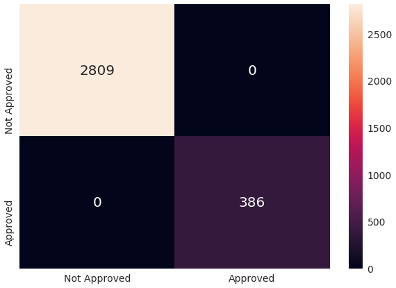

```python
df_cm = pd.DataFrame(cm)
df_cm.index = ['Not Approved', 'Approved']
df_cm.columns = ['Not Approved', 'Approved']
names=['Not Approved', 'Approved']
print(df_cm)
fig = plt.figure(figsize = (10,7))
sns.set(font_scale=1.4)#for label size
sns.heatmap(df_cm, annot=True,fmt="d",annot_kws={"size": 20})#
```

Decision Tree Classifier

```python
from pyspark.ml.classification import DecisionTreeClassifier
dt = DecisionTreeClassifier(labelCol="label", featuresCol="features")
```

```python
dt_Pipeline = Pipeline(stages=preprocessiong_Stages+[dt])

dt_Pipeline_model = dt_Pipeline.fit(trainingData)
```

```python
train_predictions_dt = dt_Pipeline_model.transform(trainingData)
test_predictions_dt = dt_Pipeline_model.transform(testData)
```

```python
from pyspark.ml.evaluation import MulticlassClassificationEvaluator
predictionAndLabels_train_dt = train_predictions_dt.select("prediction", "label")
evaluator = MulticlassClassificationEvaluator(metricName="accuracy")
train_accuracy = evaluator.evaluate(predictionAndLabels_train_dt)
print("Train set accuracy  = " + str(train_accuracy))
print("Train Error = %g" % (1.0 - train_accuracy))

predictionAndLabels_test_dt = test_predictions_dt.select("prediction", "label")
test_accuracy = evaluator.evaluate(predictionAndLabels_test_dt)
print("Test set accuracy = " + str(test_accuracy))
print("Test Error = %g" % (1.0 - test_accuracy))
```

```
Train set accuracy  = 1.0
Train Error = 0
Test set accuracy = 1.0
Test Error = 0
```

```python
true_positive = predictionAndLabels_train_dt[(predictionAndLabels_train_dt.label == 1) & (predictionAndLabels_train_dt.prediction == 1.0)].count()
true_negative = predictionAndLabels_train_dt[(predictionAndLabels_train_dt.label == 0) & (predictionAndLabels_train_dt.prediction == 0.0)].count()
false_positive = predictionAndLabels_train_dt[(predictionAndLabels_train_dt.label == 0) & (predictionAndLabels_train_dt.prediction == 1.0)].count()
false_negative = predictionAndLabels_train_dt[(predictionAndLabels_train_dt.label == 1) & (predictionAndLabels_train_dt.prediction == 0.0)].count()
print "TRAIN METRICS - DECISSION TREE CLASSIFIER"
print "True Positives:", true_positive
print "True Negatives:", true_negative
print "False Positives:", false_positive
print "False Negatives:", false_negative
print "Total", predictionAndLabels_train_dt.count()
precission = true_positive / float(true_positive + false_positive)
print "Precission: ", precission
recall = true_positive / float(true_positive + false_negative)
print "Recall: ", recall
print "F1 Score: ", (2*((precission * recall)/float(precission + recall)))
print("*****************************************************************************")
true_positive = predictionAndLabels_test_dt[(predictionAndLabels_test_dt.label == 1) & (predictionAndLabels_test_dt.prediction == 1.0)].count()
true_negative = predictionAndLabels_test_dt[(predictionAndLabels_test_dt.label == 0) & (predictionAndLabels_test_dt.prediction == 0.0)].count()
false_positive = predictionAndLabels_test_dt[(predictionAndLabels_test_dt.label == 0) & (predictionAndLabels_test_dt.prediction == 1.0)].count()
false_negative = predictionAndLabels_test_dt[(predictionAndLabels_test_dt.label == 1) & (predictionAndLabels_test_dt.prediction == 0.0)].count()
print "\n\nTEST METRICS - DECISSION TREE CLASSIFIER"
print "True Positives:", true_positive
print "True Negatives:", true_negative
print "False Positives:", false_positive
print "False Negatives:", false_negative
print "Total", predictionAndLabels_train_dt.count()
precission = true_positive / float(true_positive + false_positive)
print "Precission: ", precission
recall = true_positive / float(true_positive + false_negative)
print "Recall: ", recall
print "F1 Score: ", (2*((precission * recall)/float(precission + recall)))
```

```
TRAIN METRICS - DECISSION TREE CLASSIFIER
True Positives: 386
True Negatives: 2809
False Positives: 0
False Negatives: 0
Total 3195
Precission:  1.0
Recall:  1.0
F1 Score:  1.0


TEST METRICS - DECISSION TREE CLASSIFIER
True Positives: 135
True Negatives: 1191
False Positives: 0
False Negatives: 0
Total 3195
Precission:  1.0
Recall:  1.0
F1 Score:  1.0
```

Random Forest Classifier

```python
from pyspark.ml.classification import RandomForestClassifier
rf = RandomForestClassifier(labelCol="label", featuresCol="features", numTrees=10)
```

```python
rf_Pipeline = Pipeline(stages=preprocessiong_Stages+[rf])
rf_Pipeline_model = rf_Pipeline.fit(trainingData)
```

```python
train_predictions_rf = rf_Pipeline_model.transform(trainingData)
test_predictions_rf = rf_Pipeline_model.transform(testData)
```

```python
from pyspark.ml.evaluation import MulticlassClassificationEvaluator
predictionAndLabels_train_rf = train_predictions_rf.select("prediction", "label")
evaluator = MulticlassClassificationEvaluator(metricName="accuracy")
train_accuracy = evaluator.evaluate(predictionAndLabels_train_rf)
print("Train set accuracy  = " + str(train_accuracy))
print("Train Error = %g" % (1.0 - train_accuracy))

predictionAndLabels_test_rf = test_predictions_rf.select("prediction", "label")
test_accuracy = evaluator.evaluate(predictionAndLabels_test_rf)
print("Test set accuracy = " + str(test_accuracy))
print("Test Error = %g" % (1.0 - test_accuracy))
```

```
Train set accuracy  = 0.984350547731
Train Error = 0.0156495
Test set accuracy = 0.975867269985
Test Error = 0.0241327
```

```python
true_positive = predictionAndLabels_train_rf[(predictionAndLabels_train_rf.label == 1) & (predictionAndLabels_train_rf.prediction == 1.0)].count()
true_negative = predictionAndLabels_train_rf[(predictionAndLabels_train_rf.label == 0) & (predictionAndLabels_train_rf.prediction == 0.0)].count()
false_positive = predictionAndLabels_train_rf[(predictionAndLabels_train_rf.label == 0) & (predictionAndLabels_train_rf.prediction == 1.0)].count()
false_negative = predictionAndLabels_train_rf[(predictionAndLabels_train_rf.label == 1) & (predictionAndLabels_train_rf.prediction == 0.0)].count()
print "TRAIN METRICS - RANDOM FOREST CLASSIFIER"
print "True Positives:", true_positive
print "True Negatives:", true_negative
print "False Positives:", false_positive
print "False Negatives:", false_negative
print "Total", predictionAndLabels_train_rf.count()
precission = true_positive / float(true_positive + false_positive)
print "Precission: ", precission
recall = true_positive / float(true_positive + false_negative)
print "Recall: ", recall
print "F1 Score: ", (2*((precission * recall)/float(precission + recall)))
print("*****************************************************************************")

true_positive = predictionAndLabels_test_rf[(predictionAndLabels_test_rf.label == 1) & (predictionAndLabels_test_rf.prediction == 1.0)].count()
true_negative = predictionAndLabels_test_rf[(predictionAndLabels_test_rf.label == 0) & (predictionAndLabels_test_rf.prediction == 0.0)].count()
false_positive = predictionAndLabels_test_rf[(predictionAndLabels_test_rf.label == 0) & (predictionAndLabels_test_rf.prediction == 1.0)].count()
false_negative = predictionAndLabels_test_rf[(predictionAndLabels_test_rf.label == 1) & (predictionAndLabels_test_rf.prediction == 0.0)].count()
print "TEST METRICS - RANDOM FOREST CLASSIFIER"
print "True Positives:", true_positive
print "True Negatives:", true_negative
print "False Positives:", false_positive
print "False Negatives:", false_negative
print "Total", predictionAndLabels_train_rf.count()
#precission = true_positive / float(true_positive + false_positive)
print "Precission: ", precission
recall = true_positive / float(true_positive + false_negative)
print "Recall: ", recall
print "F1 Score: ", (2*((precission * recall)/float(precission + recall)))
```

```
TRAIN METRICS - RANDOM FOREST CLASSIFIER
True Positives: 336
True Negatives: 2809
False Positives: 0
False Negatives: 50
Total 3195
Precission:  1.0
Recall:  0.870466321244
F1 Score:  0.930747922438
TEST METRICS - RANDOM FOREST CLASSIFIER
True Positives: 103
True Negatives: 1191
False Positives: 0
False Negatives: 32
Total 3195
Precission:  1.0
Recall:  0.762962962963
F1 Score:  0.865546218487
```